# Packet 1 - Introduction to Data and Visualization

Todd CadwalladerOlsker

*Last updated:* 2022-01-28

## Part 1: Complete the R/RStudio Tutorial

If you haven’t done so yet, you should complete the R and RStudio tutorial at https://www.dataquest.io/blog/tutorial-getting-started-with-r-and-rstudio/ and follow all steps through step 15. This will give you a good grounding in R and RStudio.

## Part 2: Play around with data visualization.

In this class, we’ll be spending a lot of time playing around with data. Today, we’ll start by looking at some data and seeing what we can do with it. To begin, let’s create a pretty picture. Type the following code into the ‘console’ window of RStudio:

```r
install.packages("openintro")
install.packages("tidyverse")
library(openintro)
library(tidyverse)
```

This code installs and loads two packages: The first is `openintro`, a package containing data sets used in the OpenIntro textbooks. The second is `tidyverse`, a package of useful functions that we will be making quite a bit of use of. You only need to `install.packages()` once for each package, but you will need to use the `library()` commands every time you start a new R session.

With that out of the way, let’s look at some data. Try this:

```r
View(county)
```

There are lots of ways to get a summary, or at least a small glimpse at what your data looks like. Try typing any or all of the following functions into R:

```r
dim(county)
str(county)
summary(county)
colnames(county)
head(county)
tail(county)
# and definitely look at...
help(county)
```

The `summary()` function looks useful, but maybe we are just interested in a particular variable. We can look at a single variable using the dollar sign `$` operation:

```r
summary(county$pop2017)
summary(county$state)
summary(county$median_edu)
```

Let’s draw a picture. First, a scatterplot:

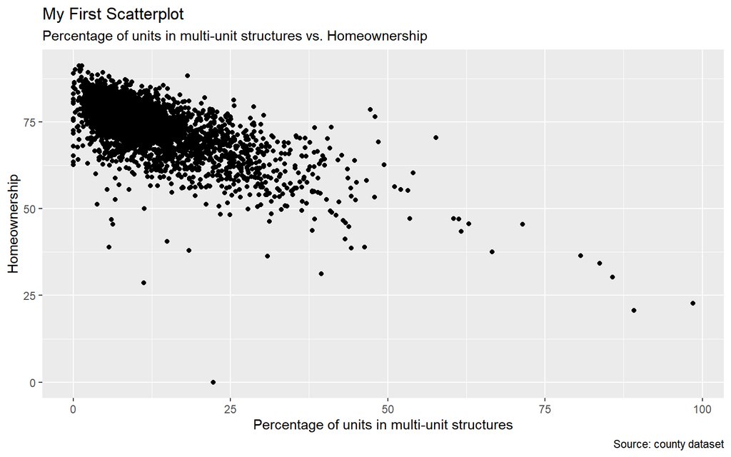

```r
ggplot(data = county) +
  geom_point(mapping = aes(x = multi_unit, y = homeownership)) +
  labs(subtitle = "Percentage of units in multi-unit structures vs. Homeownership",
       y = "Homeownership",
       x = "Percentage of units in multi-unit structures",
       title = "My First Scatterplot",
       caption = "Source: county dataset"
       )
```

What’s that data point way off to the right? Which county has nearly 100% of its housing units in multi-unit structures?

```r
filter(county,multi_unit>95)
```

We could also arrange our data by the `multi_unit` variable in descending order:

```r
arrange(county,desc(multi_unit))
```

Another useful way to think about R functions is to utilise the ‘pipe operator’, `%>%`. This takes a thing, and allows you to pipe it into the first argument of a function. For example, try:

```r
county %>% arrange(desc(multi_unit))
```

This should give you the same output as above. This can be really useful if we want to chain a bunch of ideas together:

```r
county_ca <- county %>%
  filter(state == "California") %>%
  arrange(desc(pop2017))
```

In the above code, we created a new data frame, `county_ca`, to store our modified data frame. Try `View(county_ca)` before going any further.

Another useful function is `mutate`. This allows us to create new variables in our data frame based on the data. You may have noticed when you looked at `help(county)` that the variable `pop_change` denotes the population change from 2010 to 2017. What if we want to know the population change from 2000 to 2017? Try this:

```r
county_alt <- county %>%
  mutate(pop_change_2000 = (pop2017 - pop2000) / pop2000 * 100)
```

`View(county_alt)` to see the results!

We can plot a scatterplot for our modified data. Check out https://r4ds.had.co.nz/data-visualisation.html for lots of ideas for different plots we can make with `ggplot()`. For now, try typing in the code below, and as you go, try to guess what each function in the plot does:

```r
ggplot(data = county_alt) +
  scale_color_brewer(palette="Set1") +
  geom_point(mapping = aes(x = poverty, y = pop_change_2000, color=metro)) +
  geom_smooth(mapping = aes(x = poverty, y = pop_change_2000), color="forestgreen") +
  labs(subtitle = "Poverty vs Population Change from 2000 to 2017",
       y = "Population Change from 2000 to 2017",
       x = "Poverty in 2017",
       title = "My second Scatterplot",
       caption = "Source: county dataset"
  )
```

## Part 3: Learn the basics of R Markdown

In RStudio, install the R Markdown package: `install.packages("rmarkdown")` You may wish to read through the tutorial at https://www.dataquest.io/blog/r-markdown-guide-cheatsheet/, but we’ll be doing things a little bit differently, as we want to produce .pdf documents.

1. Install `rmarkdown` with `install.packages("rmarkdown")`. This may already be installed, but there’s no harm in running the command if it is installed.
2. You don’t need to `library(rmarkdown)`, that will happen automatically when we compile (“knit” in R lingo) the file.
3. Install the `tinytex` package with `install.packages("tinytex")`.
4. `library(tinytex)`. This package creates a function to install a minimal LaTeX setup that R can interact with, which you’ll run in the next step.
5. Now, run `install_tinytex()`. This will finish the installation of the LaTeX setup.
6. Finally, let’s test everything out: in RStudio, click on File > New File > R Markdown. In the popup that appears, enter Packet 1 as the title, your name as the author, and choose PDF for the output type. Then click OK. What will appear is a template that shows off some of the features of R Markdown. Click the **Knit** button too create a PDF from this template. Notice how the R Markdown commands create output in the PDF file.

## To turn in for this packet:

For this assignment packet, you will create a report in .pdf format with RMarkdown. Your file will be turned in through the assignment page in Canvas.

Your report should include your reflections on the following two items:

1. You will create a few visualizations of a dataset, and comment on what you see.
2. You will read a short article on the relation of mathematics to politics, justice, and identity, and write a short reflection on it.

### For the first task

Run `help(climate70)` to learn about the `climate70` data set included in `openintro`. Then run `glimpse(climate70)` to see a small section of what the data looks like.

1. First, create a scatterplot showing the latitude of each weather station on the y-axis, and longitude on the x-axis. How can you interpret this plot?
2. Run the following R code (as a reminder, you only need to install packages once, but you will need to re-run the `library` commands each time you restart R:

```r
install.packages("maps")
library(maps)
world_coordinates <- map_data("world")
climate70 %>% ggplot(aes(x = longitude, y = latitude)) +
  geom_map(
    data = world_coordinates, map = world_coordinates,
    aes(long, lat, map_id = region)
  ) +
  geom_point(color="red")
```

What does this code appear to tell you about the data set? Include an R chunk containing the above code in your file, and tell me what you see.

3. Create a scatterplot with the following attributes:
- Filter your data so it only includes weather stations in North America, and
- plot latitude on the x-axis, and number of days above 70 on the y axis.

Do these two variables appear to be related? Again, include an R chunk that displays your code and the resulting scatterplot.

4. Make a second scatterplot, again filtering so only stations in North America appear, but this time compare longitude (on the x-axis) to number of days above 70 (on the y-axis). Do these variables appear to be related?
5. Finally, use `mutate` to create a variable called `diff_70` for the difference between the number of days above 70 in 1948 and the number of days above 70 in 2018. Store this data frame as `climate70_diff`. Then, create a histogram for the differences using a command like

```r
climate70_diff %>% ggplot() +
  geom_histogram(aes(x = diff_70),binwidth=5,color="black",fill="forestgreen")
```

Feel free to play around with different bin widths, colors, etc. Throughout all of this, make sure your R code appears along with your plots in your .pdf document.

### For the second task

Read the post, “Supremum/Supremacy,” by Brian Katz, at the (now discontinued) AMS Inclusion/Exclusion blog: https://blogs.ams.org/inclusionexclusion/2017/05/04/supremumsupremacy/

After reading it, write a short (2-3 paragraphs) reflection on this article. As part of your reflection, you may with to consider questions like the following: (this is not a checklist of questions to answer, only some ideas to get you thinking.)

- Do you agree with the author’s claim that mathematics is political?
- How has your own learning or teaching been affected by issues of identity?
- How do you think of yourself as a mathematical professional, and does this article challenge that image at all?